# Clustering Credit Card Customers for Targeted Marketing using Unsupervised Learning

# CSML1000 Project #2, by Group 8

Tamer Hanna tamerh@my.yorku.ca Pete Gray ptgray@my.yorku.ca Xiaohai Lu yu271637@my.yorku.ca Haofeng Zhou zhf85@my.yorku.ca

```r
library(dplyr);
library(ggplot2);
library(knitr);
library(validate);
library(tidyverse);  # data manipulation
library(cluster);    # clustering algorithms
```

# OVERVIEW

Using data on the behaviour of credit card customers, we can use unsupervised learning to discover market segments that would be useful for targeting marketing strategies.

# BUSINESS UNDERSTANDING

Applying specific marketing strategies to different types of customers can improve results and reduce costs. Credit card customers can be profiled by the way they use, and pay off, their card.

## Business Objectives

Behavioural data can be mined to discover identifying features of clusters of customers who use their card in similar ways. The marketing department can use these insights to select target groups and optimize the marketing used to target them.

## Data Mining Goals

# DATA UNDERSTANDING

## Collect Initial Data

Load the data from the local filesystem:

```r
#load data
df <- read.csv("credit-card-cust-behav-data.csv", stringsAsFactors = FALSE, header = TRUE, encoding  = "UTF-8")
```

Output a quick and dirty summary of the dataset, to ensure that we haven’t loaded something scrambled, or the wrong thing:

```r
str(df)
```

```
## 'data.frame':    8950 obs. of  18 variables:
##  $ CUST_ID                         : chr  "C10001" "C10002" "C10003" "C10004" ...
##  $ BALANCE                         : num  40.9 3202.5 2495.1 1666.7 817.7 ...
##  $ BALANCE_FREQUENCY               : num  0.818 0.909 1 0.636 1 ...
##  $ PURCHASES                       : num  95.4 0 773.2 1499 16 ...
##  $ ONEOFF_PURCHASES                : num  0 0 773 1499 16 ...
##  $ INSTALLMENTS_PURCHASES          : num  95.4 0 0 0 0 ...
##  $ CASH_ADVANCE                    : num  0 6443 0 206 0 ...
##  $ PURCHASES_FREQUENCY             : num  0.1667 0 1 0.0833 0.0833 ...
##  $ ONEOFF_PURCHASES_FREQUENCY      : num  0 0 1 0.0833 0.0833 ...
##  $ PURCHASES_INSTALLMENTS_FREQUENCY: num  0.0833 0 0 0 0 ...
##  $ CASH_ADVANCE_FREQUENCY          : num  0 0.25 0 0.0833 0 ...
##  $ CASH_ADVANCE_TRX                : int  0 4 0 1 0 0 0 0 0 0 ...
##  $ PURCHASES_TRX                   : int  2 0 12 1 1 8 64 12 5 3 ...
##  $ CREDIT_LIMIT                    : num  1000 7000 7500 7500 1200 1800 13500 2300 7000 11000 ...
##  $ PAYMENTS                        : num  202 4103 622 0 678 ...
##  $ MINIMUM_PAYMENTS                : num  140 1072 627 NA 245 ...
##  $ PRC_FULL_PAYMENT                : num  0 0.222 0 0 0 ...
##  $ TENURE                          : int  12 12 12 12 12 12 12 12 12 12 ...
```

## Explore Data

We’ll plot some basic graphs, to ensure that the data conform to our limited domain understanding.

Balance vs. Credit Limit - we would expect to find a strong correlation here, even if only because those with small credit limits must have small balances. We certainly find it.

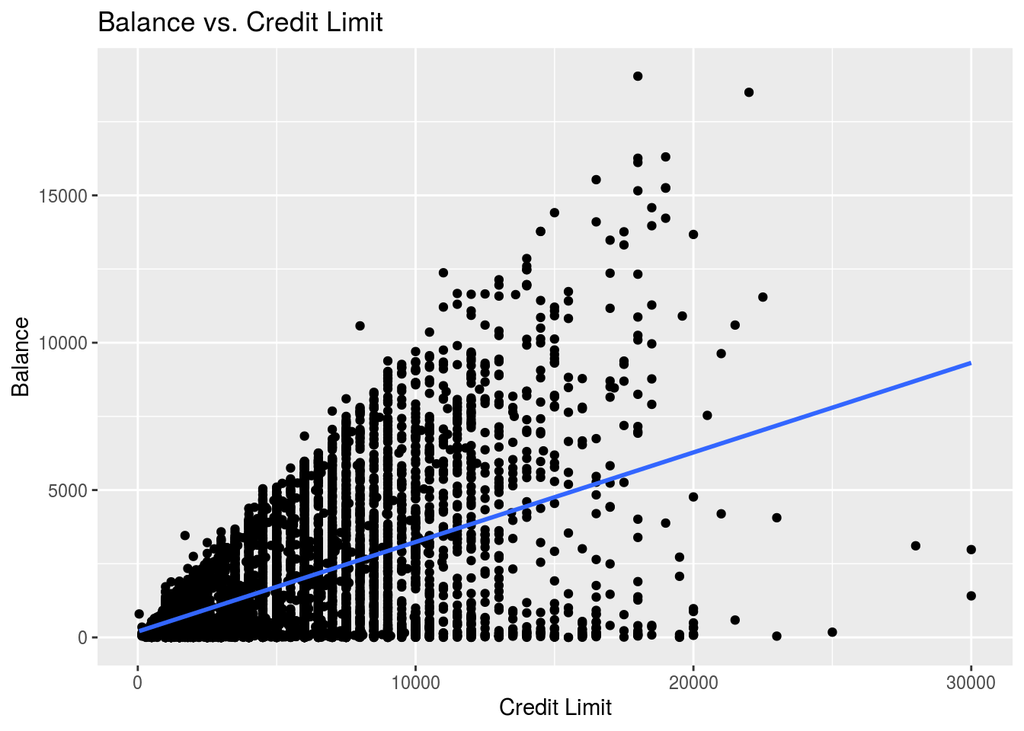

```r
df %>% ggplot(aes(y=BALANCE, x=CREDIT_LIMIT)) +
  geom_point() +
  geom_smooth(method = lm, se = FALSE) +
  labs(title="Balance vs. Credit Limit", x="Credit Limit", y="Balance")
```

Maybe those who pay higher portion of balance purchase more one-offs? No, this graph is pretty junky and doesn’t tell us anything.

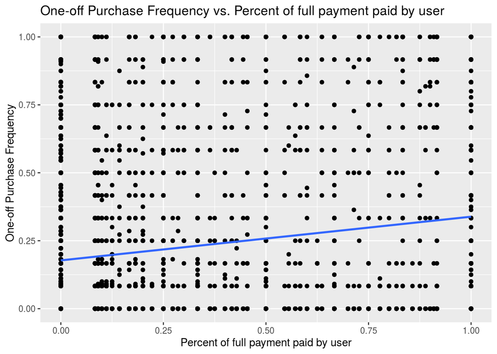

```r
df %>% ggplot(aes(y=ONEOFF_PURCHASES_FREQUENCY, x=PRC_FULL_PAYMENT)) +
  geom_point() +
  geom_smooth(method = lm, se = FALSE) +
  labs(title="One-off Purchase Frequency vs. Percent of full payment paid by user", x="Percent of full payment paid by user", y="One-off Purchase Frequency")
```

Here we can see that there appears to be a correlation between a customers credit limit, and the frequency of their purchases. Not surprising, given that frequent purchasing is one factor that leads to an increased credit limit.

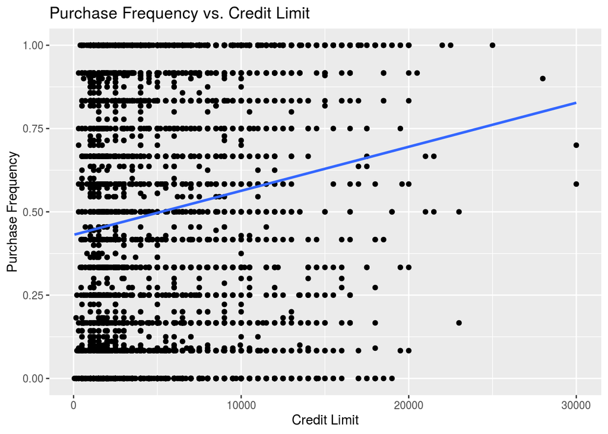

```r
df %>% ggplot(aes(y=PURCHASES_FREQUENCY, x=CREDIT_LIMIT)) +
  geom_point() +
  geom_smooth(method = lm, se = FALSE) +
  labs(title="Purchase Frequency vs. Credit Limit", x="Credit Limit", y="Purchase Frequency")
```

Higher credit limit, more purchases? Maybe. This graph is an excellent showcase of “outliers”. Only a small handful of the 9,000 records show a credit limit, or purchases, greater than $20,000. This will be one of our guiding intuitions when we get to the Data Cleaning phase.

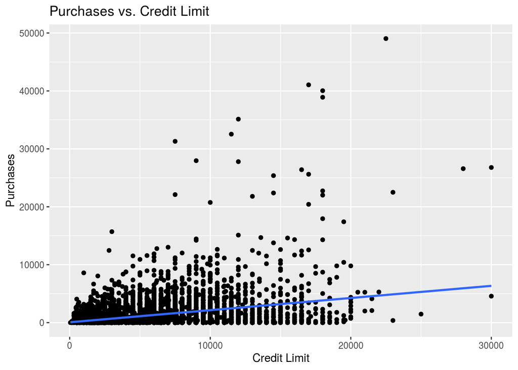

```r
df %>% ggplot(aes(y=PURCHASES, x=CREDIT_LIMIT)) +
  geom_point() +
  geom_smooth(method = lm, se = FALSE) +
  labs(title="Purchases vs. Credit Limit", x="Credit Limit", y="Purchases")
```

It would appear that those who pay off thier balance, do not take cash advances. No surprises, but a little hard to read because of the scale. One thing that appears in this graphs is a large “column” of people who are completely unlikely to pay off their entire balance, and take cash advances with very high frequency. (It is likely that the marketing department may have less interest in these people, than in others. But we’ll see!)

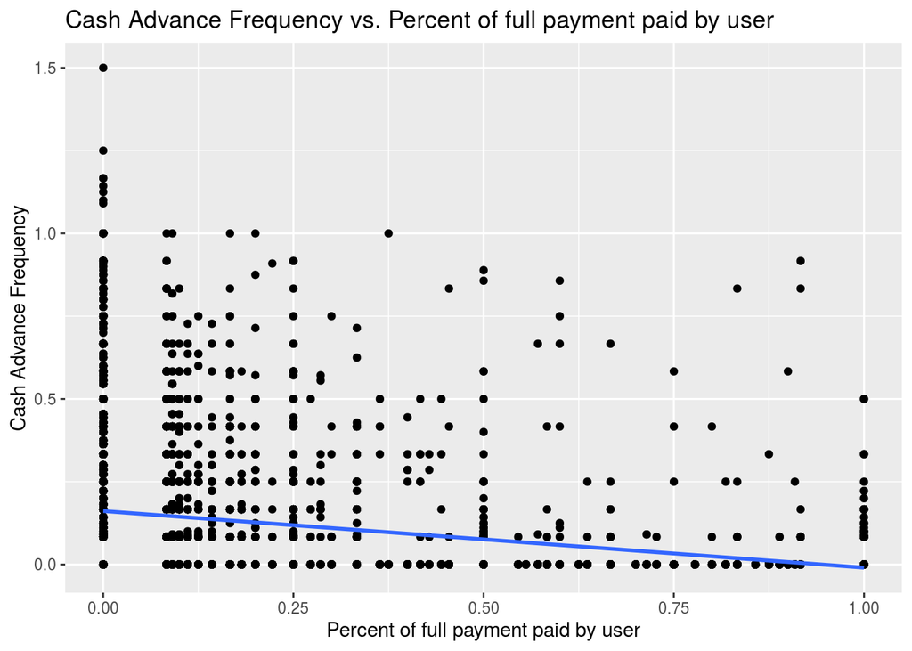

```r
df %>% ggplot(aes(y=CASH_ADVANCE_FREQUENCY, x=PRC_FULL_PAYMENT)) +
  geom_point() +
  geom_smooth(method = lm, se = FALSE) +
  labs(title="Cash Advance Frequency vs. Percent of full payment paid by user", x="Percent of full payment paid by user", y="Cash Advance Frequency")
```

One last graph, as part of our data exploration and sanity check. This one shows that there is a clear corrleation between a customer’s credit limit, and their frequency of one-off purchases. By now, we can be comfortable that our data isn’t erratic, and that our limited domain knowledge isn’t out to lunch.

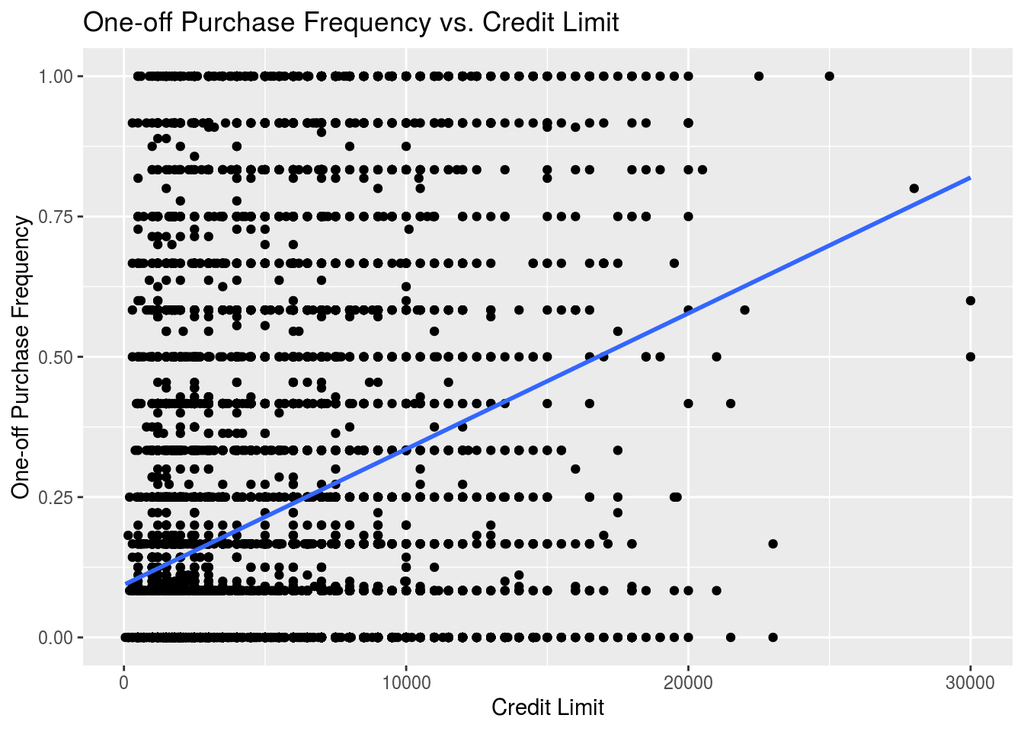

```r
df %>% ggplot(aes(y=ONEOFF_PURCHASES_FREQUENCY, x=CREDIT_LIMIT)) +
  geom_point() +
  geom_smooth(method = lm, se = FALSE) +
  labs(title="One-off Purchase Frequency vs. Credit Limit", x="Credit Limit", y="One-off Purchase Frequency")
```

## Verify Data Quality

Check if data greater than zero, look for missing data

```r
cf <- check_that(df, BALANCE > 0, BALANCE_FREQUENCY > 0, PURCHASES > 0, ONEOFF_PURCHASES > 0, INSTALLMENTS_PURCHASES > 0, CASH_ADVANCE > 0, PURCHASES_FREQUENCY > 0, ONEOFF_PURCHASES_FREQUENCY > 0, PURCHASES_INSTALLMENTS_FREQUENCY > 0, CASH_ADVANCE_FREQUENCY > 0, PURCHASES_TRX > 0, CREDIT_LIMIT > 0, MINIMUM_PAYMENTS > 0, PRC_FULL_PAYMENT > 0, TENURE > 0, BALANCE/CREDIT_LIMIT < 1)
summary(cf)
```

```
##    name items passes fails nNA error warning
## 1   V01  8950   8870    80   0 FALSE   FALSE
## 2   V02  8950   8870    80   0 FALSE   FALSE
## 3   V03  8950   6906  2044   0 FALSE   FALSE
## 4   V04  8950   4648  4302   0 FALSE   FALSE
## 5   V05  8950   5034  3916   0 FALSE   FALSE
## 6   V06  8950   4322  4628   0 FALSE   FALSE
## 7   V07  8950   6907  2043   0 FALSE   FALSE
## 8   V08  8950   4648  4302   0 FALSE   FALSE
## 9   V09  8950   5035  3915   0 FALSE   FALSE
## 10  V10  8950   4322  4628   0 FALSE   FALSE
## 11  V11  8950   6906  2044   0 FALSE   FALSE
## 12  V12  8950   8949     0   1 FALSE   FALSE
## 13  V13  8950   8637     0 313 FALSE   FALSE
## 14  V14  8950   3047  5903   0 FALSE   FALSE
```

[output cut: 19 more lines]

There appear to be a great number of zeroes. Let’s look at that a little more closely:

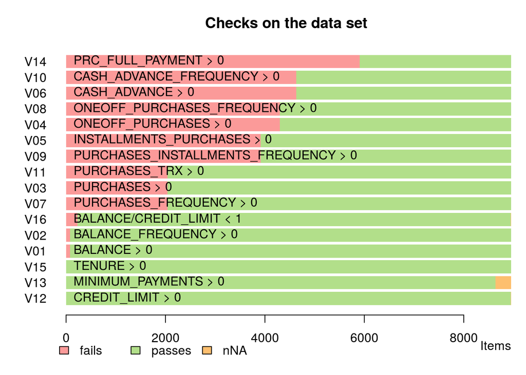

```r
barplot(cf,main="Checks on the data set")
```

Lots of zero! Though, using our limitied knowledge of this domain, we can understand that this could be perfectly reasonable. In the first few lines of the above chart, we can see that a lot of people never make the full payment, a lot of people never get a cash advance, and some people didn’t even make a purchase. Seems entirely reasonable. We can note too that the “zeroes” in PURCHASES_TRX, PURCHASES, and PURCHASES_FREQUENCY appear to be identical. In line with what we’d expect!

Now let’s include zero, and see how it all stacks up for Greater OR Equal to zero:

```r
cf <- check_that(df, BALANCE >= 0, BALANCE_FREQUENCY >= 0, PURCHASES >= 0, ONEOFF_PURCHASES >= 0, INSTALLMENTS_PURCHASES >= 0, CASH_ADVANCE >= 0, PURCHASES_FREQUENCY >= 0, ONEOFF_PURCHASES_FREQUENCY >= 0, PURCHASES_INSTALLMENTS_FREQUENCY >= 0, CASH_ADVANCE_FREQUENCY >= 0, PURCHASES_TRX >= 0, CREDIT_LIMIT >= 0, MINIMUM_PAYMENTS >= 0, PRC_FULL_PAYMENT >= 0, TENURE >= 0, BALANCE/CREDIT_LIMIT <= 1)
summary(cf)
```

```
##    name items passes fails nNA error warning
## 1   V01  8950   8950     0   0 FALSE   FALSE
## 2   V02  8950   8950     0   0 FALSE   FALSE
## 3   V03  8950   8950     0   0 FALSE   FALSE
## 4   V04  8950   8950     0   0 FALSE   FALSE
## 5   V05  8950   8950     0   0 FALSE   FALSE
## 6   V06  8950   8950     0   0 FALSE   FALSE
## 7   V07  8950   8950     0   0 FALSE   FALSE
## 8   V08  8950   8950     0   0 FALSE   FALSE
## 9   V09  8950   8950     0   0 FALSE   FALSE
## 10  V10  8950   8950     0   0 FALSE   FALSE
## 11  V11  8950   8950     0   0 FALSE   FALSE
## 12  V12  8950   8949     0   1 FALSE   FALSE
## 13  V13  8950   8637     0 313 FALSE   FALSE
## 14  V14  8950   8950     0   0 FALSE   FALSE
```

[output cut: 19 more lines]

Our only serious problems remaining are some N/As in Minimum Payment. We also see that a few people have a balance greater than their credit limit - this would not constitue a problem with the data. Simply a problem the customer in question is having. (Their balance is higher than their credit limit)

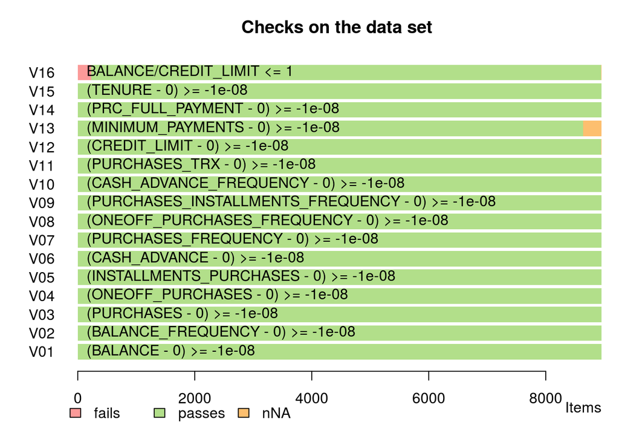

```r
barplot(cf,main="Checks on the data set")
```

As a last look at the data, let’s look at the variance of the individual columns.

```r
var(df$BALANCE)
```

```
## [1] 4332775
```

```r
var(df$BALANCE_FREQUENCY)
```

```
## [1] 0.05612351
```

```r
var(df$PURCHASES)
```

```
## [1] 4565208
```

```r
var(df$ONEOFF_PURCHASES)
```

```
## [1] 2755228
```

```r
var(df$INSTALLMENTS_PURCHASES)
```

```
## [1] 817827.4
```

```r
var(df$CASH_ADVANCE)
```

```
## [1] 4398096
```

```r
var(df$PURCHASES_FREQUENCY)
```

```
## [1] 0.1610985
```

```r
var(df$ONEOFF_PURCHASES_FREQUENCY)
```

```
## [1] 0.08900441
```

```r
var(df$PURCHASES_INSTALLMENTS_FREQUENCY)
```

```
## [1] 0.1579647
```

```r
var(df$CASH_ADVANCE_FREQUENCY)
```

```
## [1] 0.04004857
```

```r
var(df$CASH_ADVANCE_TRX)
```

```
## [1] 46.5758
```

```r
var(df$PURCHASES_TRX)
```

```
## [1] 617.9027
```

```r
var(df$CREDIT_LIMIT)
```

```
## [1] NA
```

```r
var(df$PAYMENTS)
```

```
## [1] 8381394
```

```r
var(df$MINIMUM_PAYMENTS)
```

```
## [1] NA
```

```r
var(df$PRC_FULL_PAYMENT)
```

```
## [1] 0.08555578
```

```r
var(df$TENURE)
```

```
## [1] 1.791129
```

The data appear to have more information in the “amount” columns, and less in the “frequency” columns. We’ll test this assumption when we try some modelling.

# DATA PREPARATION

## Select Data

We saw that MINIMUM_PAYMENTS is riddled with N/As, so let’s remove that column. This should be compatible with our Business Objectives, as we’re hoping to get people to spend, rather than optimize their repayments.

```r
df$MINIMUM_PAYMENTS <- NULL
```

There was one nasty little N/A in CREDIT_LIMIT, let’s remove that row so we can use that column.

```r
df <- na.omit(df)
```

## Clean Data

During the Data Exploration phase, we discovered that of the 9,000 rows of data, there are a handful that have much higher values that all the rest. While we are certainly interested in these customers, they can be easily found without expensive machine learning. Simple code can be used to scrape off the customers with a credit limit, or purchases, higher than some amount.

As we’re hoping to come up with customer segments that are a significant portion of our customer base, perhaps containing hundreds or thousands of customers, let’s look at “capping” some of these extreme values, to see if it moderates these few extreme outliers and suggests more patterns at a smaller scale.

First, here’s the graph that drew this to our attention:

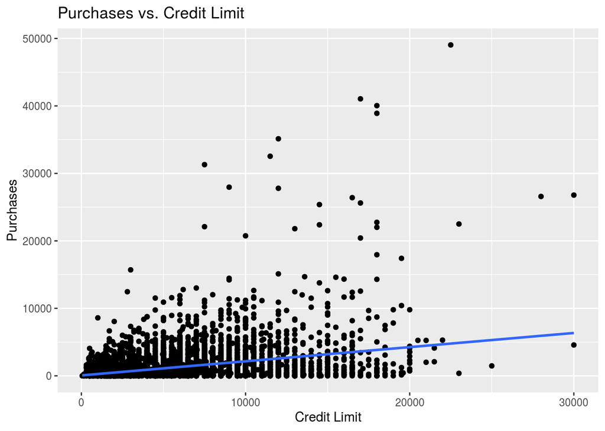

```r
df %>% ggplot(aes(y=PURCHASES, x=CREDIT_LIMIT)) +
  geom_point() +
  geom_smooth(method = lm, se = FALSE) +
  labs(title="Purchases vs. Credit Limit", x="Credit Limit", y="Purchases")
```

Let’s cap those two variables at $20,000 and see if it seems a little less crazy:

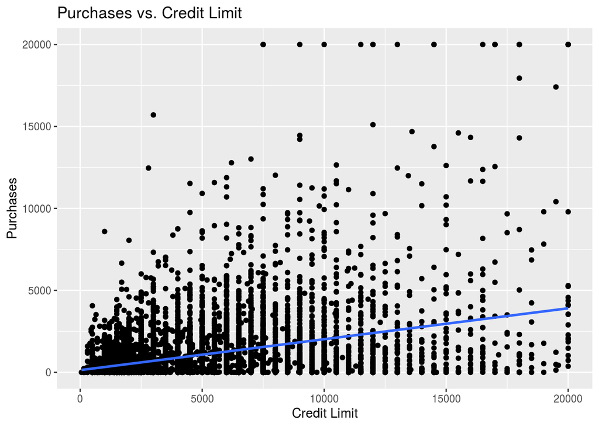

```r
df$CREDIT_LIMIT[df$CREDIT_LIMIT > 20000 ] <- 20000
df$PURCHASES[df$PURCHASES > 20000 ] <- 20000
df %>% ggplot(aes(y=PURCHASES, x=CREDIT_LIMIT)) +
  geom_point() +
  geom_smooth(method = lm, se = FALSE) +
  labs(title="Purchases vs. Credit Limit", x="Credit Limit", y="Purchases")
```

How about if we capped them at a smaller number, would it get silly? Or would it show us more variance inside the dense part of the distribution?

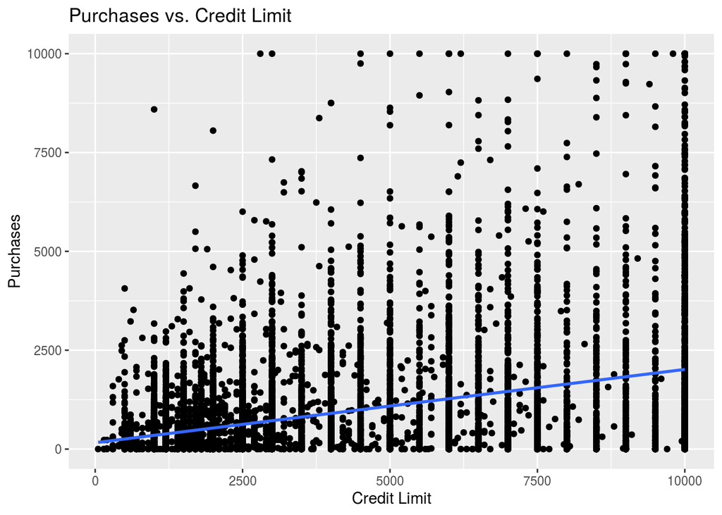

```r
df$CREDIT_LIMIT[df$CREDIT_LIMIT > 10000 ] <- 10000
df$PURCHASES[df$PURCHASES > 10000 ] <- 10000
df %>% ggplot(aes(y=PURCHASES, x=CREDIT_LIMIT)) +
  geom_point() +
  geom_smooth(method = lm, se = FALSE) +
  labs(title="Purchases vs. Credit Limit", x="Credit Limit", y="Purchases")
```

Well, I don’t like that. Too many Credit Limits at or above 10,000. Though, that doesn’t seem a problem with Purchases.

Let’s reset the data, and cap the values differently.

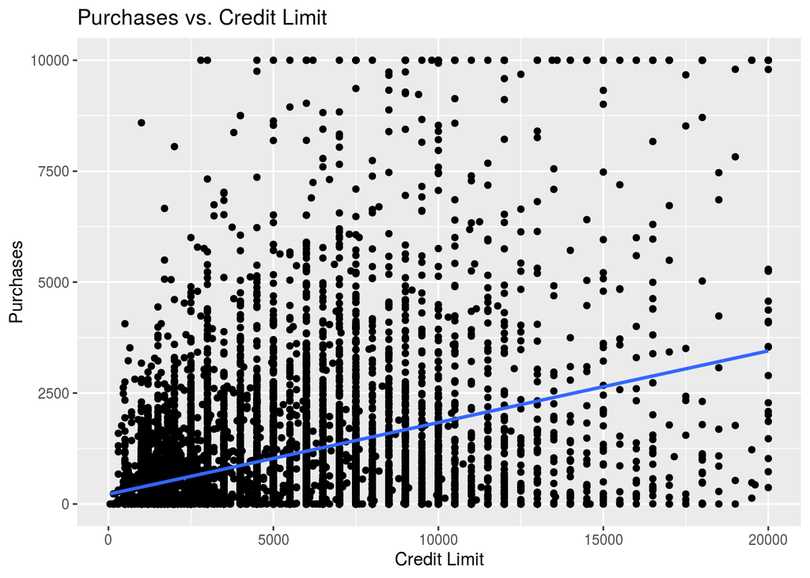

```r
#load data
df <- read.csv("credit-card-cust-behav-data.csv", stringsAsFactors = FALSE, header = TRUE, encoding  = "UTF-8")
df$MINIMUM_PAYMENTS <- NULL
df <- na.omit(df)

df$CREDIT_LIMIT[df$CREDIT_LIMIT > 20000 ] <- 20000
df$PURCHASES[df$PURCHASES > 10000 ] <- 10000

df %>% ggplot(aes(y=PURCHASES, x=CREDIT_LIMIT)) +
  geom_point() +
  geom_smooth(method = lm, se = FALSE) +
  labs(title="Purchases vs. Credit Limit", x="Credit Limit", y="Purchases")
```

That seems much better, both for the purchases, and the credit limit.

Let’s look at one variable at a time, to ensure we haven’t created a big distortion out at the high end:

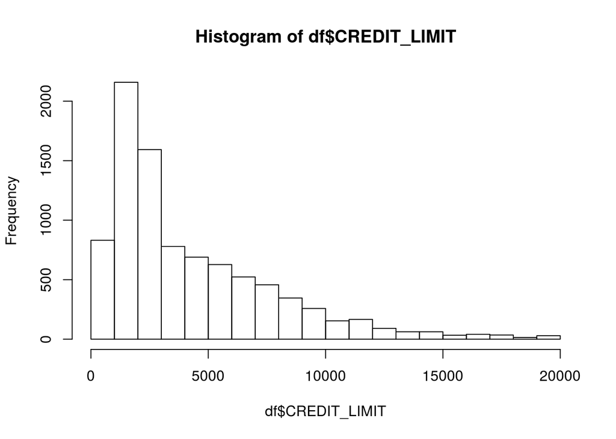

```r
hist(df$CREDIT_LIMIT)
```

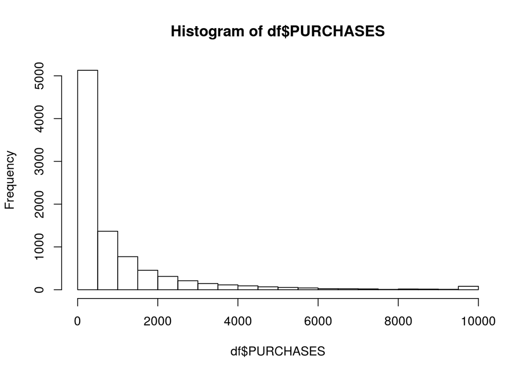

```r
hist(df$PURCHASES)
```

Seems okay. Let’s look at the distribution of some of the other big-value columns that we’re most interested in, to see how they look.

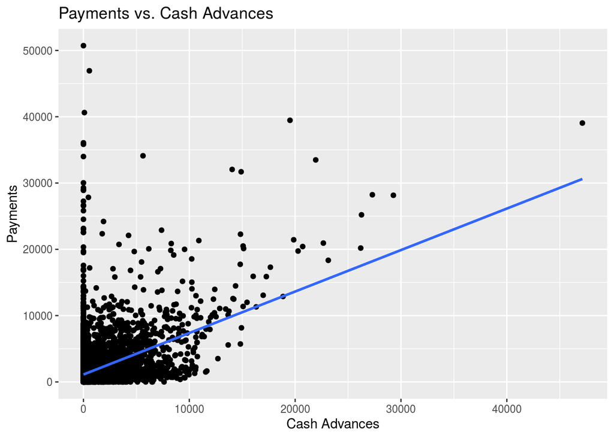

```r
df %>% ggplot(aes(y=PAYMENTS, x=CASH_ADVANCE)) +
  geom_point() +
  geom_smooth(method = lm, se = FALSE) +
  labs(title="Payments vs. Cash Advances", x="Cash Advances", y="Payments")
```

Wow, that’s some serious outliers. Let’s cap them.

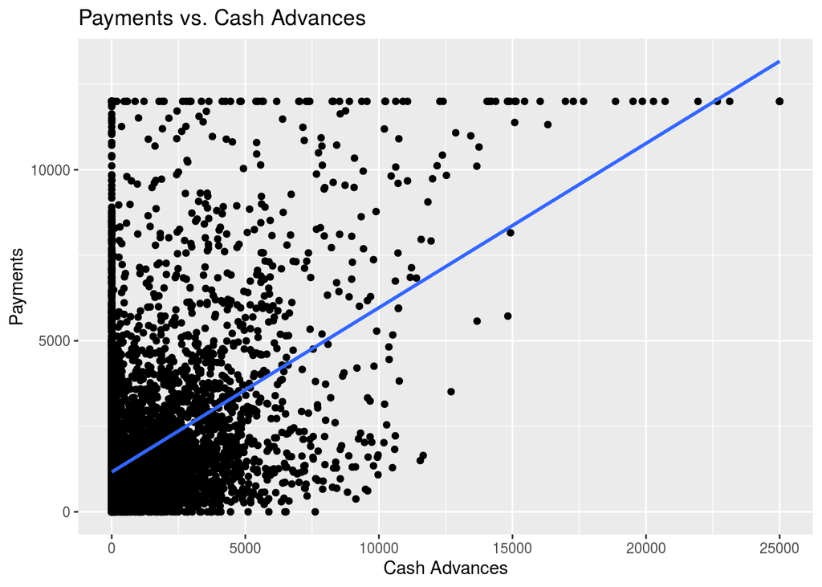

```r
df$PAYMENTS[df$PAYMENTS > 12000 ] <- 12000
df$CASH_ADVANCE[df$CASH_ADVANCE > 25000 ] <- 25000

df %>% ggplot(aes(y=PAYMENTS, x=CASH_ADVANCE)) +
  geom_point() +
  geom_smooth(method = lm, se = FALSE) +
  labs(title="Payments vs. Cash Advances", x="Cash Advances", y="Payments")
```

Two more columns we’re very interested in using need to be check for this:

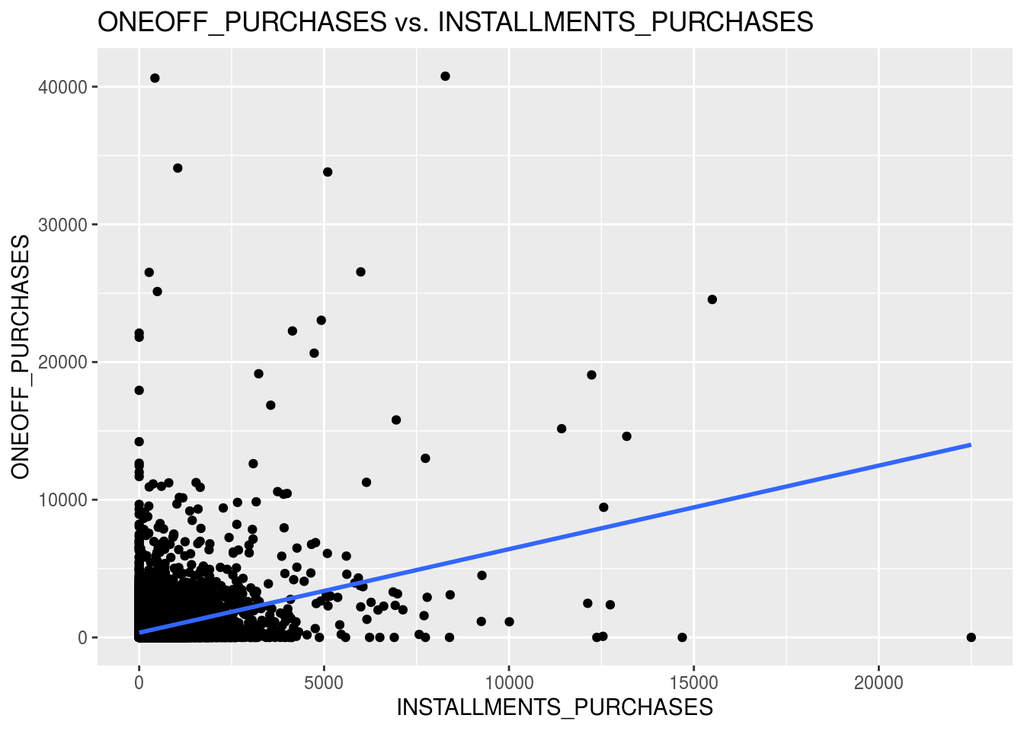

```r
df %>% ggplot(aes(y=ONEOFF_PURCHASES, x=INSTALLMENTS_PURCHASES)) +
  geom_point() +
  geom_smooth(method = lm, se = FALSE) +
  labs(title="ONEOFF_PURCHASES vs. INSTALLMENTS_PURCHASES", x="INSTALLMENTS_PURCHASES", y="ONEOFF_PURCHASES")
```

A very few extreme outliers. Let’s bring them a little closer to the group:

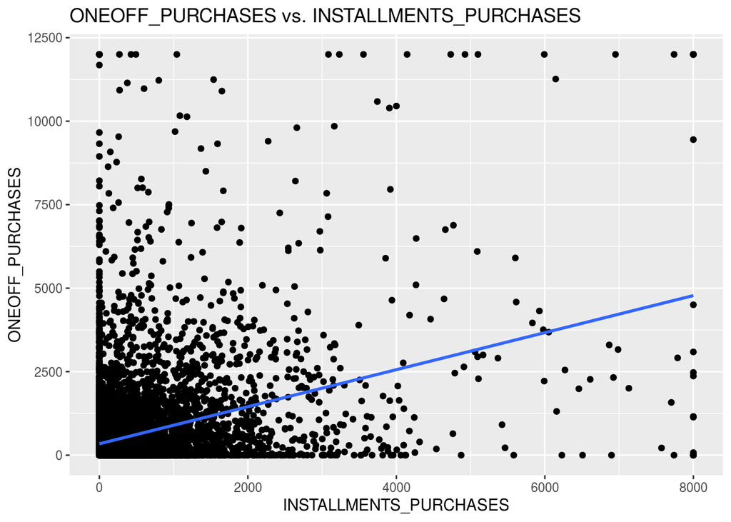

```r
df$ONEOFF_PURCHASES[df$ONEOFF_PURCHASES > 12000 ] <- 12000
df$INSTALLMENTS_PURCHASES[df$INSTALLMENTS_PURCHASES > 8000 ] <- 8000

df %>% ggplot(aes(y=ONEOFF_PURCHASES, x=INSTALLMENTS_PURCHASES)) +
  geom_point() +
  geom_smooth(method = lm, se = FALSE) +
  labs(title="ONEOFF_PURCHASES vs. INSTALLMENTS_PURCHASES", x="INSTALLMENTS_PURCHASES", y="ONEOFF_PURCHASES")
```

Let us try with this, and we can compare it to fresh, uncapped data when we get to modelling.

## Construct Data

## Integrate Data

## Format Data

# MODELING

## Select Modeling Technique

K-Means, we try first.

## Generate Test Design

# Determine number of clusters

Run tests on various numbers of clusters to look for an “elbow” which will suggest how many useful clusters we can hope to get from this data.

First, we’ll do it with many columns, so we can compare to much smaller number more of our choosing.

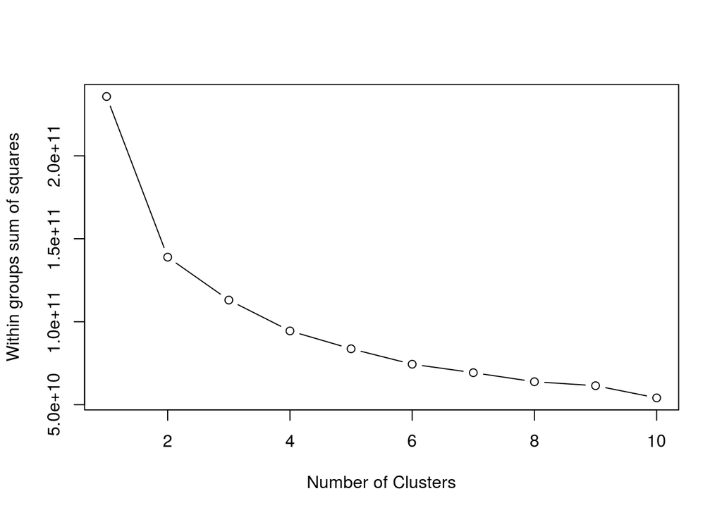

```r
cld <- df[c(2:14)]

wss <- (nrow(cld)-1)*sum(apply(cld,2,var))
for (i in 2:10) wss[i] <- sum(kmeans(cld,
   centers=i)$withinss)
plot(1:10, wss, type="b", xlab="Number of Clusters",
  ylab="Within groups sum of squares")
```

Here’s the same test, but performed only with BALANCE, PURCHASES, ONEOFF_PURCHASES, INSTALLMENTS_PURCHASES, and CASH_ADVANCE.

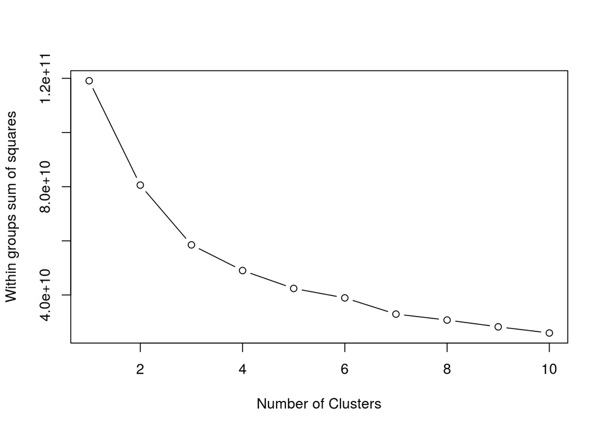

```r
cld <- df[c(2,4:7)]

wss <- (nrow(cld)-1)*sum(apply(cld,2,var))
for (i in 2:10) wss[i] <- sum(kmeans(cld,
   centers=i)$withinss)
plot(1:10, wss, type="b", xlab="Number of Clusters",
  ylab="Within groups sum of squares")
```

We’ve definitely lost some of our predicting power with only those columns - let’s add CREDIT_LIMIT back in to see if that helps:

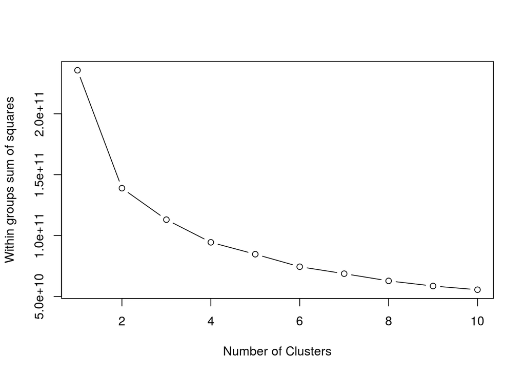

```r
cld <- df[c(2,4:7, 14)]

wss <- (nrow(cld)-1)*sum(apply(cld,2,var))
for (i in 2:10) wss[i] <- sum(kmeans(cld,
   centers=i)$withinss)
plot(1:10, wss, type="b", xlab="Number of Clusters",
  ylab="Within groups sum of squares")
```

In terms of how many clusters we should choose, these graphs could be suggesting anywhere from 4 to 7, depending on how we read them. We’ll try a few things.